# a3_task4_nikole_vannest

Nikole Vannest

11/2/2020

# Task 4

### Naples Reef purple urchins

```r
knitr::opts_chunk$set(echo = TRUE, message=F, warning=F)
library(tidyverse)
library(here)
library(janitor)
library(lubridate)
library(kableExtra)
```

### Read in data and clean up names

```r
urchins_raw <- read.csv(here("data", "urchins.csv"))
urchins <- urchins_raw %>%
  clean_names()
```

```r
nr_2010 <- urchins %>%
  mutate(date = mdy(date)) %>%
  mutate(month = month(date)) %>%
  mutate(year = year(date)) %>%
  filter(common_name == "Purple Urchin", #Filter for purple species
         site == "NAPL", #Keep only obs in Naples Reef
         month == 1, #Keep only obs in January
         year == 2010) #Keep only obs in 2010
```

Exploratory QQ plot and histogram

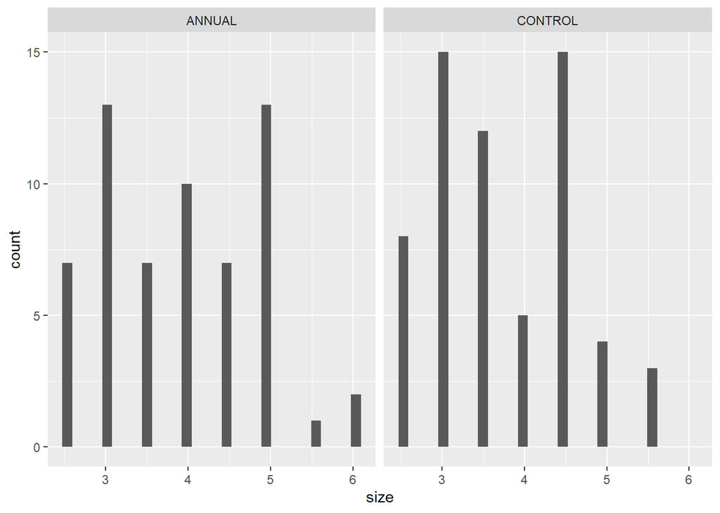

```r
ggplot(nr_2010, aes(x = size)) + #exploratory histogram
  geom_histogram() +
  facet_wrap(~treatment)
```

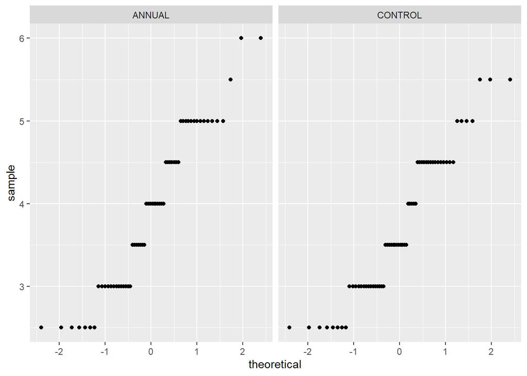

```r
ggplot(nr_2010, aes(sample = size)) + #exploratory QQ plot
  geom_qq() +
  facet_wrap(~treatment)
```

Summary table of statistics

```r
nr_table <- nr_2010 %>% #table of summary statistics
  group_by(treatment) %>%
  summarize(mean = mean(size),
            median = median(size),
            sd = sd(size),
            n = n())

nr_table %>% #View table output
  kable() %>%
  kable_styling(latex_options = "styling down")
```

| treatment | mean | median | sd | n |
| --- | --- | --- | --- | --- |
| ANNUAL | 3.916667 | 4.0 | 0.9662380 | 60 |
| CONTROL | 3.725807 | 3.5 | 0.8668646 | 62 |

T-test

```r
control_sample <- nr_2010 %>%
  filter(treatment == "CONTROL") %>%
  pull(size)

annual_sample <- nr_2010 %>%
  filter(treatment == "ANNUAL") %>%
  pull(size)

t.test(x = control_sample, y = annual_sample)
```

```
##
##  Welch Two Sample t-test
##
## data:  control_sample and annual_sample
## t = -1.1472, df = 117.66, p-value = 0.2536
## alternative hypothesis: true difference in means is not equal to 0
## 95 percent confidence interval:
##  -0.5203369  0.1386165
## sample estimates:
## mean of x mean of y
##  3.725806  3.916667
```

```r
percent_diff <- abs((mean(control_sample) - mean(annual_sample))/((mean(control_sample) + mean(annual_sample))/2))*100

percent_diff
```

```
## [1] 4.994724
```

**Comprehensive statement:** Two treatments were tested here, control and annual kelp removal. In the graphs and tables above, we are looking at how these treatments have affected the diameter of Purple urchin populations in Naples Reef. Based on the information provided by the exploratory graphs as well as the t-test and calculating the percent difference, it would seem that there is not a significant difference between the two treatments. The p-value is 0.2536, and the percent difference of the means is only 5%. Such a high p-value would indicate that there is a high probability that any difference we would observe in samples occurs due to random chance, and that these two sets of data are not significantly different enough to be two distinct groups.